# 17202278 Chill out cafe of Dublin

## OBJECTIVE:

- Use an API to fetch data
- Pre-processing and cleaning data
- Analysing the Data
- Visualise the observations

## Introduction:

I used Yelp API to gather data and do following assessment:

- Finding the best area to have 'Tea & Coffee' by the user rating and the number of reviews.
- Sentimental analysis of the reviews.
- Finding top trends in the data and generating a list of areas where best cafes are located in Dublin.
- Documenting and Visualising the top trends in the data.

## API Details:

### Yelp API:

Following are the parameters set for fetching data from Yelp using its API:

City = Dublin

API Endpoint for Business ID's: https://api.yelp.com/v3/businesses/search.json

API Endpoint for Reviews: https://api.yelp.com/v3/businesses/{id}/reviews.json

Secret API Key: **Can't Share**

API Limit-day: 25000

- The response contains all the business Id's and then using these business Id's reviews related data are fetched.
- This data is Filtered and Feature are selected to perform the analysis.
- Max of 1000 business-ids can be fetched from the given parameters.
- Max 3 reviews per business id is returned from the API.

###### Details of the API Used:

Yelp Fusion API: https://www.yelp.ie/developers/documentation/v3

## Topic: Coffee hoppers paradise in Dublin.

#### Importing all the required libraries:

```python
import pandas as pd
import numpy as np
import matplotlib.pyplot as plt
import seaborn as sns
import requests
import io
import csv
import json
import urllib.parse
import sys
import warnings
from pandas.tools.plotting import table
import matplotlib
from textblob import TextBlob

# To see the plots inline
%matplotlib inline

# Ignoring some warnings
if not sys.warnoptions:
    warnings.simplefilter("ignore")
```

#### Secret key for data retrieval from Yelp API:

```python
api_key = **Cant Share**
```

### Data Collection is done here which is further used for analysis.

##### Data Collection:

Data collection is the process of gathering and measuring information on targeted variables in an established systematic fashion.

import_data is the function which is performing the API calls and fetching the data in the json format.

clean_data is the function where data from is read individually from json data and then sent to the collect_data function.

collect_data is the function to fetch the relevant details from the json data, where Business_ID, Price, Rating, Number of reviews, City, Zip Code is fetched and all the information is stored into the CSV file named 'data_analysis.csv' which is created on the run.

```python
# open a csv file to store the data
data_analysis = open("data_analysis.csv","w")
# create an empty dataframe
data_dataframe = pd.DataFrame(columns=("BuisnessID","Price","Rating","NoOfReviews","City"))

# Function calls to collect_data for individual buisnesses in each city.
def clean_data(response):
    for counter in range(len(response["businesses"])):
        collect_data(response["businesses"][counter])

# Function to append the response into the created dataframe.
def collect_data(response):
    global data_dataframe
    rating = response["rating"]
    buisness_id = response["id"]
    price = response["price"]
    city = response["location"]["city"]
    zip_code = response["location"]["zip_code"]
    review_count = response["review_count"]
    # Append response to the dataframe
    data_dataframe = data_dataframe.append({
        'BuisnessID': buisness_id,
        'Price': price,
        'Rating': rating,
        'NoOfReviews': review_count,
        'City': city,
        'ZipCode': zip_code
        },ignore_index=True)


# Import data from API
def import_data():
    global data_dataframe
    # Yelp dataset Endpoint
    url = "https://api.yelp.com/v3/businesses/search"

    # authorisation header
    headers = {"Authorization": "Bearer %s" % api_key}
    yelp_data = []
    outfile = open("yelp_data.json", "w")
    # Selecting food and drinks category from Yelp API endpoint with different prices.
    for city in ['Dublin']:
        for price in range(1,5):
            print("Processing for",city,"and price", price)
            response = requests.get(url + "?location="+city+"&term=Coffee+Tea&limit=50&price=" + str(price) , headers = headers).json()
            clean_data(response)
    data_dataframe.to_csv(data_analysis, sep = ",", encoding = "utf-8")


import_data()
data_analysis.close()
```

```
Processing for Dublin and price 1
Processing for Dublin and price 2
Processing for Dublin and price 3
Processing for Dublin and price 4
```

### Here the reviews are being collected for all the businesses id's that is fetched and stored in data_analysis.csv

This had to be done as in Yelp API we need to pass the business Id's for the review collection and for each of the business id only 3 latest reviews are fetched, along with its timestamp.

import_review_data is the function which is performing the API calls and fetching the data in the json fromat.

clean_review_data is the function where data is read individually from json data and selects the relevant information i.e. Buisness ID, Review Text, Review Rating (i.e. the rating provided by the user), TimeCreated (i.e. when this review was given), City, ZipCode is appended in the dataframe 'review_dataframe'.

Then from the dataframe: Business ID, Review Text, Review Rating, City, Zip Code is fetched and the information is stored into the CSV file named 'review_analysis.csv' which is created on the run.

```python
# open qualitative analysis file
review_analysis = open("review_analysis.csv","w")

# Create an empty dataframe for analysis of reviews
review_dataframe = pd.DataFrame(columns=("BuisnessID","ReviewText","ReviewRating","TimeCreated","City","ZipCode"))

# This function is used to append response into the dataframe.
def clean_review_data(response,buisness_id, city, zip_code):
    global review_dataframe
    if "reviews" in response:
        for counter in range(len(response["reviews"])):
            review_dataframe = review_dataframe.append({
                'BuisnessID': buisness_id,
                'ReviewText': response["reviews"][counter]["text"],
                'ReviewRating': response["reviews"][counter]["rating"],
                'TimeCreated': response["reviews"][counter]["time_created"],
                'City': city,
                'ZipCode': zip_code,
        },ignore_index=True)


# This function is used to fetch data from Yelp dataset
def import_review_data():
    # Yelp Endpoint for businesses
    url = "https://api.yelp.com/v3/businesses"
    # authorisation header
    headers = {"Authorization": "Bearer %s" % api_key}
    # reading and fetching data from the previous file.
    buisness_id = pd.read_csv("data_analysis.csv", sep=',')
    # To run in Windows machine: Uncomment following line and comment the above one for proper encodings.
    # buisness_id = pd.read_csv("data_analysis.csv", sep=',', encoding="windows-1252")
    listOfbuisness = buisness_id["BuisnessID"]
    listOfCities = buisness_id["City"]
    listOfZipCodes = buisness_id["ZipCode"]
    counter = 0
    # for each business Id in the city.
    for BuisnessID, City, ZipCode in zip(listOfbuisness, listOfCities, listOfZipCodes):
        counter = counter + 1
        print("Processing for", BuisnessID, "counter", counter)
        try:
            response = requests.get(url + "/" + BuisnessID + "/reviews", headers = headers).json()
        except ConnectionError as e:
            print(e)
            response = "No response"
        except ValueError:
            print("Decoding failed.")
        clean_review_data(response, BuisnessID, City, ZipCode)
        #print("REVIEW DATAFRAME:", review_dataframe)
    #review_dataframe.to_csv("review_analysis.csv", index = None, header = True)
    print("Writing data to review_analysis.csv")
    review_dataframe.to_csv(review_analysis, sep = ",", encoding = "utf-8")

import_review_data()
review_analysis.close()
```

[output not shown]

[output cut: 96 more lines]

[output not shown]

## Data Pre-processing and Quality Checking:

In this part the gathered data is checked and cleaned, so that on further analysis we have a quality data set and it becomes easy to access and utilize.

Here from the above collected data the file is read by pandas and stored in the data frame i.e. df_shops and df_reviews.

```python
#reading data from the file

# add encoding="windows-1258" to the following lines for Windows machine
df_shops = pd.read_csv("data_analysis.csv",sep = ',')
df_reviews = pd.read_csv("review_analysis.csv", sep = ',')
# Looking at the first 5 rows of df_shops
df_shops.head()
```

|  | Unnamed: 0 | BuisnessID | Price | Rating | NoOfReviews | City | ZipCode |
| --- | --- | --- | --- | --- | --- | --- | --- |
| 0 | 0 | beanhive-dublin | € | 4.5 | 49 | Dublin | 2 |
| 1 | 1 | urbanity-coffee-dublin | € | 5.0 | 20 | Dublin | 7 |
| 2 | 2 | legit-dublin | € | 4.5 | 21 | Dublin | 8 |
| 3 | 3 | shoe-lane-coffee-dublin | € | 4.5 | 7 | Dublin | NaN |
| 4 | 4 | coffee-to-get-her-dublin | € | 4.5 | 6 | Dublin | 2 |

### Examining and aggregating the Data Set:

It is the process where raw data is gathered and expressed in a summary form for statistical analysis.

That is what each column in df_shops and df_reviews represents.

Here initially first the data frame is described, which gives us the count, mean, standard deviation, quartiles min, and max.

```python
# Description of the data:
print("Description of first data frame: \n", df_shops.describe(),"\n")
print("Description of second data frame: \n", df_reviews.describe(),"\n")

#Checkng for null values
print("Null values in first data frame: \n", df_shops.isnull().sum(),"\n")
print("Null values in second data frame: \n", df_reviews.isnull().sum(),"\n")
```

```
Description of first data frame:
        Unnamed: 0      Rating  NoOfReviews
count  150.000000  150.000000   150.000000
mean    74.500000    4.100000    32.806667
std     43.445368    0.540321    52.747810
min      0.000000    2.000000     1.000000
25%     37.250000    4.000000     6.000000
50%     74.500000    4.000000    17.000000
75%    111.750000    4.500000    33.750000
max    149.000000    5.000000   396.000000

Description of second data frame:
        Unnamed: 0  ReviewRating
count  437.000000    437.000000
mean   218.000000      4.160183
std    126.295289      1.047920
min      0.000000      1.000000
25%    109.000000      4.000000
50%    218.000000      4.000000
75%    327.000000      5.000000
max    436.000000      5.000000

Null values in first data frame:
 Unnamed: 0      0
BuisnessID      0
Price           0
Rating          0
NoOfReviews     0
City            0
ZipCode        17
dtype: int64

Null values in second data frame:
 Unnamed: 0       0
BuisnessID       0
ReviewText       0
ReviewRating     0
TimeCreated      0
City             0
ZipCode         48
dtype: int64
```

### Data Cleaning:

Data Cleaning is done to remove noise and correct inconsistencies in the data.

Here I have checked for the null values in the data, and since the null values are in the Zip Codes, on which any of the aggregating function will not be an optimal solution as it will make the data unreliable.

- Removing the Null Values.

```python
# Cleaning the data by removing all the null values:
df_shops = df_shops[pd.notnull(df_shops['ZipCode'])]
df_reviews = df_reviews[pd.notnull(df_reviews['ZipCode'])]

print("After removing the Null Values: \n")
print("Null values in first data frame: \n", df_shops.isnull().sum(),"\n")
print("Null values in second data frame: \n", df_reviews.isnull().sum(),"\n")
```

```
After removing the Null Values:

Null values in first data frame:
 Unnamed: 0     0
BuisnessID     0
Price          0
Rating         0
NoOfReviews    0
City           0
ZipCode        0
dtype: int64

Null values in second data frame:
 Unnamed: 0      0
BuisnessID      0
ReviewText      0
ReviewRating    0
TimeCreated     0
City            0
ZipCode         0
dtype: int64
```

#### Taking a look at our data frame:

```python
df_shops.head()
```

|  | Unnamed: 0 | BuisnessID | Price | Rating | NoOfReviews | City | ZipCode |
| --- | --- | --- | --- | --- | --- | --- | --- |
| 0 | 0 | beanhive-dublin | € | 4.5 | 49 | Dublin | 2 |
| 1 | 1 | urbanity-coffee-dublin | € | 5.0 | 20 | Dublin | 7 |
| 2 | 2 | legit-dublin | € | 4.5 | 21 | Dublin | 8 |
| 4 | 4 | coffee-to-get-her-dublin | € | 4.5 | 6 | Dublin | 2 |
| 5 | 5 | kaph-dublin | € | 4.0 | 87 | Dublin | 2 |

### Dropping the column which are irrelevant for our data analysis

Checking if the 'Unnamed: 0' column exists, if it exist then dropping the column.

If not then just print the head of the first data frame.

```python
if 'Unnamed: 0' in df_shops.columns:
    df_shops.drop('Unnamed: 0', axis = 1, inplace = True)
    df_reviews.drop('Unnamed: 0', axis = 1, inplace = True)

df_shops.head()
```

|  | BuisnessID | Price | Rating | NoOfReviews | City | ZipCode |
| --- | --- | --- | --- | --- | --- | --- |
| 0 | beanhive-dublin | € | 4.5 | 49 | Dublin | 2 |
| 1 | urbanity-coffee-dublin | € | 5.0 | 20 | Dublin | 7 |
| 2 | legit-dublin | € | 4.5 | 21 | Dublin | 8 |
| 4 | coffee-to-get-her-dublin | € | 4.5 | 6 | Dublin | 2 |
| 5 | kaph-dublin | € | 4.0 | 87 | Dublin | 2 |

### Normalising Data:

Normalization is often done on data so as to remove amplitude variation and only focusing on the underlying distribution.

Here the data is normalised in range of 0 and 1, by dividing the 'number of reviews' by the 'max number of reviews'. As this will differentiate the most popular shop from the rest of the shops, and all the values in the data set will be positive values.

Whereas normalising using mean will result in negative values: z(a) = (x(a)− mean(x(a))) / std(x(a))

Another way I could do is using following formula for normalisation: (x-min) / (max-min)

```python
# Normalising the number of reviews by dividing it with the max of that column.
#df_1 = df_1["NoOfReviews"]/df_1["NoOfReviews"].max()
df_shops.loc[:, df_shops.columns == 'Rating'] /= 5
df_shops.loc[:, df_shops.columns == 'NoOfReviews'] /= df_shops["NoOfReviews"].max()

df_shops.head()
```

|  | BuisnessID | Price | Rating | NoOfReviews | City | ZipCode |
| --- | --- | --- | --- | --- | --- | --- |
| 0 | beanhive-dublin | € | 0.9 | 0.123737 | Dublin | 2 |
| 1 | urbanity-coffee-dublin | € | 1.0 | 0.050505 | Dublin | 7 |
| 2 | legit-dublin | € | 0.9 | 0.053030 | Dublin | 8 |
| 4 | coffee-to-get-her-dublin | € | 0.9 | 0.015152 | Dublin | 2 |
| 5 | kaph-dublin | € | 0.8 | 0.219697 | Dublin | 2 |

### Data analysis:

Modeling data with the goal of discovering useful information, suggesting conclusions, and supporting decision-making.

Here the 'Score' of each shop is calculated based on the normalised data by adding 'Rating' & 'NoOfReviews' and summing it up and storing the value in the column 'Score'.

```python
df_shops['Score'] = (df_shops['Rating'] + df_shops['NoOfReviews'])
df_shops.head()
```

|  | BuisnessID | Price | Rating | NoOfReviews | City | ZipCode | Score |
| --- | --- | --- | --- | --- | --- | --- | --- |
| 0 | beanhive-dublin | € | 0.9 | 0.123737 | Dublin | 2 | 1.023737 |
| 1 | urbanity-coffee-dublin | € | 1.0 | 0.050505 | Dublin | 7 | 1.050505 |
| 2 | legit-dublin | € | 0.9 | 0.053030 | Dublin | 8 | 0.953030 |
| 4 | coffee-to-get-her-dublin | € | 0.9 | 0.015152 | Dublin | 2 | 0.915152 |
| 5 | kaph-dublin | € | 0.8 | 0.219697 | Dublin | 2 | 1.019697 |

### Data Sorting and Formatting:

##### Formatting:

Formatting is the process of organising information according to present specifications.

In the fetched data most of the ZipCodes were numeric, but in some of the records EIR code example 'D02 KC56' hence to take out the area code i.e. 2 in this case for Dublin Hence to do so regular expression was used.

```python
# Formatting the data just to fetch Zip Code from the EIR code
df_shops['ZipCode'] = df_shops['ZipCode'].str.extract('(\d+)').astype(int)
df_shops.head()
```

|  | BuisnessID | Price | Rating | NoOfReviews | City | ZipCode | Score |
| --- | --- | --- | --- | --- | --- | --- | --- |
| 0 | beanhive-dublin | € | 0.9 | 0.123737 | Dublin | 2 | 1.023737 |
| 1 | urbanity-coffee-dublin | € | 1.0 | 0.050505 | Dublin | 7 | 1.050505 |
| 2 | legit-dublin | € | 0.9 | 0.053030 | Dublin | 8 | 0.953030 |
| 4 | coffee-to-get-her-dublin | € | 0.9 | 0.015152 | Dublin | 2 | 0.915152 |
| 5 | kaph-dublin | € | 0.8 | 0.219697 | Dublin | 2 | 1.019697 |

### Grouping and Sorting:

Grouping all the data as per the Zip codes, which gives me the most popular place to have a cup of coffee or Tea.

Sorting is the process of arranging data into meaningful order so the data can be analyzed more effectively.

```python
df_shops = df_shops.groupby("ZipCode").sum().reset_index()
#df_gb.head(10)
rating_zipcode = df_shops.sort_values(by="Score", ascending=False).head(10)
```

#### Limiting up the decimal values up to 2 places:

Formatting the Rating and Score up to 2 decimal places.

```python
# Formatting the score up to 2 decimal places.
rating_zipcode['Score'] = rating_zipcode['Score'].map('{:,.2f}'.format)
rating_zipcode['Rating'] = rating_zipcode['Rating'].map('{:,.2f}'.format)
rating_zipcode['ZipCode'] = 'D' + rating_zipcode['ZipCode'].astype(str)

# Converting string type to numeric type.
rating_zipcode[['Score','Rating']] = rating_zipcode[['Score','Rating']].apply(pd.to_numeric)

rating_zipcode
```

|  | ZipCode | Rating | NoOfReviews | Score |
| --- | --- | --- | --- | --- |
| 1 | D2 | 54.1 | 7.227273 | 61.33 |
| 0 | D1 | 15.1 | 2.250000 | 17.35 |
| 6 | D8 | 10.9 | 0.828283 | 11.73 |
| 5 | D7 | 9.8 | 0.838384 | 10.64 |
| 3 | D4 | 7.5 | 0.318182 | 7.82 |
| 4 | D6 | 4.5 | 0.383838 | 4.88 |
| 7 | D9 | 3.4 | 0.055556 | 3.46 |
| 2 | D3 | 1.5 | 0.068182 | 1.57 |
| 8 | D16 | 1.2 | 0.045455 | 1.25 |
| 9 | D17 | 0.8 | 0.012626 | 0.81 |

## Vsiulisation Top 10 areas based on the Score.

### D: Dublin

i.e. D3: Dublin 3 (Zip Code)

#### Defining the font to be used in the representations and using magic function for better quality plots:

```python
# To get the higher quality display of graphs:
%config InlineBackend.figure_format = 'retina'

font = {'family' : 'normal',
        'weight' : 'bold',
        'size'   : 16}

matplotlib.rc('font', **font)
```

#### Plotting the bar graph for top 10 scores area wise:

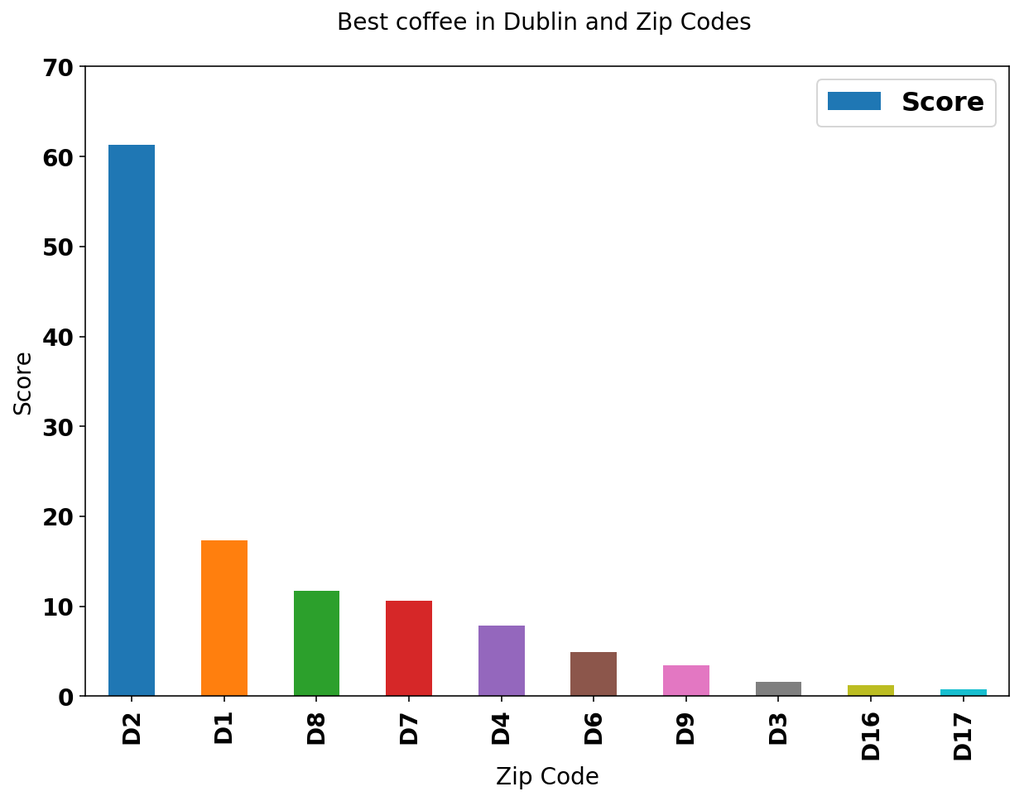

```python
def drawGraphs():
    p = rating_zipcode.plot.bar(figsize=(10,7), x="ZipCode", y="Score", fontsize=14)
    plt.title("Best coffee in Dublin and Zip Codes \n", fontsize=14)
    p.set_ylabel("Score", fontsize=14)
    p.set_xlabel("Zip Code", fontsize=14)
    plt.ylim(0,70)
    plt.show()

drawGraphs()
```

## Sentimental analysis based on the user reviews:

### Sentiment Analysis:

- It is done for systematically identify, extract and quantify the qualitative aspects.
- Determining the attitude of a reviewer or writer with respect to quality or emotional reaction, interaction.
- The attitude may be a judgment or evaluation, affective state (i.e. the emotional state of the reviewer or writer).
- To perform the sentiment analysis TextBlob library is used.

```python
# Reviews dataframe head
df_reviews.head(10)
```

|  | BuisnessID | ReviewText | ReviewRating | TimeCreated | City | ZipCode |
| --- | --- | --- | --- | --- | --- | --- |
| 0 | beanhive-dublin | Awesome staff, yummy traditional Irish food fo... | 5 | 2018-03-14 21:21:31 | Dublin | 2 |
| 1 | beanhive-dublin | Coffee is great, staff is incredibly sweet, an... | 5 | 2018-01-31 10:24:52 | Dublin | 2 |
| 2 | beanhive-dublin | After browsing the internet all night, be deci... | 3 | 2017-12-10 10:32:53 | Dublin | 2 |
| 3 | urbanity-coffee-dublin | Ham hash and coffee were both wonderful. Great... | 5 | 2018-03-18 12:09:32 | Dublin | 7 |
| 4 | urbanity-coffee-dublin | This place was AMAZING! In the cool little nei... | 5 | 2018-02-07 06:27:55 | Dublin | 7 |
| 5 | urbanity-coffee-dublin | One of my favourite cafés un Dublin! Urbanity ... | 5 | 2018-03-04 03:45:16 | Dublin | 7 |
| 6 | legit-dublin | This spot is super hip and warm! They have a t... | 5 | 2018-02-15 11:30:11 | Dublin | 8 |
| 7 | legit-dublin | Stayed at an Airbnb not far from Legit. This p... | 5 | 2018-03-25 07:31:31 | Dublin | 8 |
| 8 | legit-dublin | Had no idea Dublin had such amazing coffee. Th... | 5 | 2017-11-28 01:08:28 | Dublin | 8 |
| 12 | coffee-to-get-her-dublin | I need to update my previous five star review ... | 5 | 2016-07-07 11:43:28 | Dublin | 2 |

## Calculating the Polarity and the Subjectivity of the reviews:

### Polarity:

- It simply means emotions expressed in a sentence. It is a measure of the negativity, the neutralness, or the positivity of the text.

### Subjectivity:

- Subjective sentence expresses some personal feelings, views, or beliefs.

#### Range:

- Polarity: -1 to 1, i.e. negative to positive emotions.
- Subjectivity: value from 0 to 1 measuring the subjectivness of the text. 0 is objective, 1 is subjective.
- Calculating the Polarity and Subjectivity and storing it in the dataframe.

```python
df_reviews['Polarity'] = df_reviews.apply(lambda x: TextBlob(x['ReviewText']).sentiment.polarity, axis=1)
df_reviews['Subjectivity'] = df_reviews.apply(lambda x: TextBlob(x['ReviewText']).sentiment.subjectivity, axis=1)
df_reviews.head()
```

|  | BuisnessID | ReviewText | ReviewRating | TimeCreated | City | ZipCode | Polarity | Subjectivity |
| --- | --- | --- | --- | --- | --- | --- | --- | --- |
| 0 | beanhive-dublin | Awesome staff, yummy traditional Irish food fo... | 5 | 2018-03-14 21:21:31 | Dublin | 2 | 0.400000 | 0.596667 |
| 1 | beanhive-dublin | Coffee is great, staff is incredibly sweet, an... | 5 | 2018-01-31 10:24:52 | Dublin | 2 | 0.354167 | 0.741667 |
| 2 | beanhive-dublin | After browsing the internet all night, be deci... | 3 | 2017-12-10 10:32:53 | Dublin | 2 | 0.104167 | 0.500000 |
| 3 | urbanity-coffee-dublin | Ham hash and coffee were both wonderful. Great... | 5 | 2018-03-18 12:09:32 | Dublin | 7 | 0.396562 | 0.592500 |
| 4 | urbanity-coffee-dublin | This place was AMAZING! In the cool little nei... | 5 | 2018-02-07 06:27:55 | Dublin | 7 | 0.120000 | 0.585000 |

### Dropping and Formatting the columns:

- Dropping the columns that is not needed for the sentimental analysis
- Then formatting EIR code to fetch the Zip Code form it using regular expression.

```python
df_reviews.drop(['BuisnessID','TimeCreated'], axis = 1, inplace = True)
df_reviews['ZipCode'] = df_reviews['ZipCode'].str.extract('(\d+)').astype(int)
df_reviews.head()
```

|  | ReviewText | ReviewRating | City | ZipCode | Polarity | Subjectivity |
| --- | --- | --- | --- | --- | --- | --- |
| 0 | Awesome staff, yummy traditional Irish food fo... | 5 | Dublin | 2 | 0.400000 | 0.596667 |
| 1 | Coffee is great, staff is incredibly sweet, an... | 5 | Dublin | 2 | 0.354167 | 0.741667 |
| 2 | After browsing the internet all night, be deci... | 3 | Dublin | 2 | 0.104167 | 0.500000 |
| 3 | Ham hash and coffee were both wonderful. Great... | 5 | Dublin | 7 | 0.396562 | 0.592500 |
| 4 | This place was AMAZING! In the cool little nei... | 5 | Dublin | 7 | 0.120000 | 0.585000 |

## Based on the Polarity score, Reviews are categorised:

#### * Positive: If the polarity score is greater than .35 then the statement is considered as positive.

#### * Negative: If the polarity score is smaller than than -.35 then the statement is considered as negative.

#### * Neutral: If the polarity score is between -.34 and .34 then the statement is considered as neutral.

- This is done as the 'range of polarity' varies from -1 to 1.
- For 1 being very happy or Positive
- And -1 being very bad or Negative.

Hence we have i.e. 2 points (-1 to 1) and dividing it by 3 features namely Positive, Neutral and Negative. Thereby the polarity is being further categorised into 3 features.

#### And 3 are columns are added in the dataframe as Positive, Negative and Neutral based on the score.

```python
df_reviews['Positive'] = np.where(df_reviews.Polarity >= .35,1,0)
df_reviews['Negative'] = np.where(df_reviews.Polarity <= -0.35,1,0)
df_reviews['Neutral'] = np.where(np.logical_and(df_reviews.Polarity > -0.34, df_reviews.Polarity < .34),1,0)
df_reviews.head()
```

|  | ReviewText | ReviewRating | City | ZipCode | Polarity | Subjectivity | Positive | Negative | Neutral |
| --- | --- | --- | --- | --- | --- | --- | --- | --- | --- |
| 0 | Awesome staff, yummy traditional Irish food fo... | 5 | Dublin | 2 | 0.400000 | 0.596667 | 1 | 0 | 0 |
| 1 | Coffee is great, staff is incredibly sweet, an... | 5 | Dublin | 2 | 0.354167 | 0.741667 | 1 | 0 | 0 |
| 2 | After browsing the internet all night, be deci... | 3 | Dublin | 2 | 0.104167 | 0.500000 | 0 | 0 | 1 |
| 3 | Ham hash and coffee were both wonderful. Great... | 5 | Dublin | 7 | 0.396562 | 0.592500 | 1 | 0 | 0 |
| 4 | This place was AMAZING! In the cool little nei... | 5 | Dublin | 7 | 0.120000 | 0.585000 | 0 | 0 | 1 |

### Grouping the data as per area i.e. Zip Codes

```python
# Grouping the data as per area i.e. Zip Codes
review_rating = df_reviews.groupby("ZipCode").sum().reset_index()
review_rating.head(10)
```

|  | ZipCode | ReviewRating | Polarity | Subjectivity | Positive | Negative | Neutral |
| --- | --- | --- | --- | --- | --- | --- | --- |
| 0 | 1 | 237 | 15.222467 | 28.363603 | 24 | 1 | 28 |
| 1 | 2 | 808 | 58.043086 | 117.693119 | 92 | 2 | 101 |
| 2 | 3 | 22 | 1.608021 | 3.278333 | 2 | 0 | 4 |
| 3 | 4 | 115 | 7.466250 | 16.781845 | 13 | 1 | 13 |
| 4 | 6 | 63 | 5.466419 | 7.709896 | 8 | 0 | 6 |
| 5 | 7 | 152 | 12.311231 | 19.256312 | 17 | 0 | 16 |
| 6 | 8 | 163 | 12.339287 | 24.640168 | 14 | 0 | 24 |
| 7 | 9 | 41 | 1.760556 | 5.046944 | 2 | 0 | 9 |
| 8 | 16 | 17 | 0.680853 | 3.919742 | 1 | 0 | 5 |
| 9 | 17 | 12 | 1.306250 | 1.556250 | 1 | 0 | 2 |

### Sorting the data frame for the maximum polarity:

```python
# Using 'Sort_values' to sort the data, and making ascending as False to get the top scores i.e in Descending order.
review_rating_Polarity = review_rating
review_rating_Polarity.sort_values(['Polarity'], ascending=False, inplace=True)
review_rating_Polarity.head(10)
```

|  | ZipCode | ReviewRating | Polarity | Subjectivity | Positive | Negative | Neutral |
| --- | --- | --- | --- | --- | --- | --- | --- |
| 1 | 2 | 808 | 58.043086 | 117.693119 | 92 | 2 | 101 |
| 0 | 1 | 237 | 15.222467 | 28.363603 | 24 | 1 | 28 |
| 6 | 8 | 163 | 12.339287 | 24.640168 | 14 | 0 | 24 |
| 5 | 7 | 152 | 12.311231 | 19.256312 | 17 | 0 | 16 |
| 3 | 4 | 115 | 7.466250 | 16.781845 | 13 | 1 | 13 |
| 4 | 6 | 63 | 5.466419 | 7.709896 | 8 | 0 | 6 |
| 7 | 9 | 41 | 1.760556 | 5.046944 | 2 | 0 | 9 |
| 2 | 3 | 22 | 1.608021 | 3.278333 | 2 | 0 | 4 |
| 9 | 17 | 12 | 1.306250 | 1.556250 | 1 | 0 | 2 |
| 8 | 16 | 17 | 0.680853 | 3.919742 | 1 | 0 | 5 |

### Sorting the data frame for the maximum Subjectivity:

```python
# Using 'Sort_values' to sort the data, and making ascending as False to get the top scores i.e in Descending order.
review_rating_Subjectivity = review_rating.sort_values(by="Subjectivity", ascending=False).head(10)
review_rating_Subjectivity
```

|  | ZipCode | ReviewRating | Polarity | Subjectivity | Positive | Negative | Neutral |
| --- | --- | --- | --- | --- | --- | --- | --- |
| 1 | 2 | 808 | 58.043086 | 117.693119 | 92 | 2 | 101 |
| 0 | 1 | 237 | 15.222467 | 28.363603 | 24 | 1 | 28 |
| 6 | 8 | 163 | 12.339287 | 24.640168 | 14 | 0 | 24 |
| 5 | 7 | 152 | 12.311231 | 19.256312 | 17 | 0 | 16 |
| 3 | 4 | 115 | 7.466250 | 16.781845 | 13 | 1 | 13 |
| 4 | 6 | 63 | 5.466419 | 7.709896 | 8 | 0 | 6 |
| 7 | 9 | 41 | 1.760556 | 5.046944 | 2 | 0 | 9 |
| 8 | 16 | 17 | 0.680853 | 3.919742 | 1 | 0 | 5 |
| 2 | 3 | 22 | 1.608021 | 3.278333 | 2 | 0 | 4 |
| 9 | 17 | 12 | 1.306250 | 1.556250 | 1 | 0 | 2 |

#### Formatting Polarity Dataframe:

Formatting is the process of organising information according to present specifications, i.e. converting the numeric data into 2 decimal places.

Appending 'D' to represent Dublin, in the Zip Code.

```python
# Formatting the score up to 2 decimal places.
review_rating_Polarity['Polarity'] = review_rating_Polarity['Polarity'].map('{:,.2f}'.format)
review_rating_Polarity['Subjectivity'] = review_rating_Polarity['Subjectivity'].map('{:,.2f}'.format)
review_rating_Polarity['ZipCode'] = 'D' + review_rating_Polarity['ZipCode'].astype(str)

# Converting string type to numeric type.
review_rating_Polarity[['Polarity','Subjectivity']] = review_rating_Polarity[['Polarity','Subjectivity']].apply(pd.to_numeric)
review_rating_Polarity.head()
```

|  | ZipCode | ReviewRating | Polarity | Subjectivity | Positive | Negative | Neutral |
| --- | --- | --- | --- | --- | --- | --- | --- |
| 1 | D2 | 808 | 58.04 | 117.69 | 92 | 2 | 101 |
| 0 | D1 | 237 | 15.22 | 28.36 | 24 | 1 | 28 |
| 6 | D8 | 163 | 12.34 | 24.64 | 14 | 0 | 24 |
| 5 | D7 | 152 | 12.31 | 19.26 | 17 | 0 | 16 |
| 3 | D4 | 115 | 7.47 | 16.78 | 13 | 1 | 13 |

#### Formatting Subjectivity Dataframe:

Formatting is the process of organising information according to present specifications, i.e. converting the numeric data into 2 decimal places.

Appending 'D' to represent Dublin, in the Zip Code.

```python
# Formatting the score up to 2 decimal places.
review_rating_Subjectivity['Polarity'] = review_rating_Subjectivity['Polarity'].map('{:,.2f}'.format)
review_rating_Subjectivity['Subjectivity'] = review_rating_Subjectivity['Subjectivity'].map('{:,.2f}'.format)
review_rating_Subjectivity['ZipCode'] = 'D' + review_rating_Subjectivity['ZipCode'].astype(str)

# Converting string type to numeric type.
review_rating_Subjectivity[['Polarity','Subjectivity']] = review_rating_Subjectivity[['Polarity','Subjectivity']].apply(pd.to_numeric)
review_rating_Subjectivity.head()
```

|  | ZipCode | ReviewRating | Polarity | Subjectivity | Positive | Negative | Neutral |
| --- | --- | --- | --- | --- | --- | --- | --- |
| 1 | D2 | 808 | 58.04 | 117.69 | 92 | 2 | 101 |
| 0 | D1 | 237 | 15.22 | 28.36 | 24 | 1 | 28 |
| 6 | D8 | 163 | 12.34 | 24.64 | 14 | 0 | 24 |
| 5 | D7 | 152 | 12.31 | 19.26 | 17 | 0 | 16 |
| 3 | D4 | 115 | 7.47 | 16.78 | 13 | 1 | 13 |

## Visualisations:

#### * The below plot shows the relationship between the Polarity and the Subjectivity, i.e.

### Plot between 'Emotions expressed in review' vs 'Personal feelings or views in review'

[figure not shown]

```python
g = sns.lmplot( x="Subjectivity", y="Polarity", hue="ZipCode", truncate=True, size=6, data=review_rating)
g = plt.title("Relationship between the Polarity and the Subjectivity for Top 10 Areas \n", fontsize=14)
```

#### On score basis Dublin 2 is far ahead from all the rest of the remaining areas.

```python
review_rating_Polarity.head()
```

|  | ZipCode | ReviewRating | Polarity | Subjectivity | Positive | Negative | Neutral |
| --- | --- | --- | --- | --- | --- | --- | --- |
| 1 | D2 | 808 | 58.04 | 117.69 | 92 | 2 | 101 |
| 0 | D1 | 237 | 15.22 | 28.36 | 24 | 1 | 28 |
| 6 | D8 | 163 | 12.34 | 24.64 | 14 | 0 | 24 |
| 5 | D7 | 152 | 12.31 | 19.26 | 17 | 0 | 16 |
| 3 | D4 | 115 | 7.47 | 16.78 | 13 | 1 | 13 |

### Visualising the data based on 'Polarity' for Top 6 Areas:

|  | ZipCode | ReviewRating | Polarity | Subjectivity | Positive | Negative | Neutral |
| --- | --- | --- | --- | --- | --- | --- | --- |
| 1 | D2 | 808 | 58.04 | 117.69 | 92 | 2 | 101 |
| 0 | D1 | 237 | 15.22 | 28.36 | 24 | 1 | 28 |
| 6 | D8 | 163 | 12.34 | 24.64 | 14 | 0 | 24 |
| 5 | D7 | 152 | 12.31 | 19.26 | 17 | 0 | 16 |
| 3 | D4 | 115 | 7.47 | 16.78 | 13 | 1 | 13 |
| 4 | D6 | 63 | 5.47 | 7.71 | 8 | 0 | 6 |

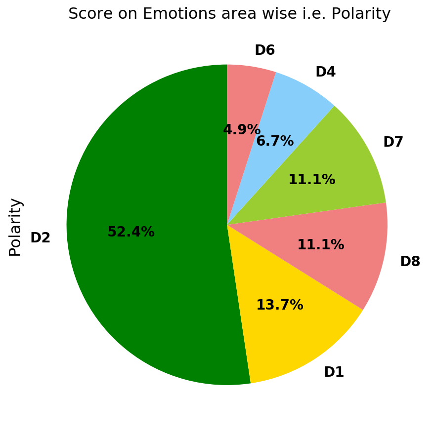

```python
review_rating_Polarity_Plot = review_rating_Polarity.head(6)
# Figure size of the plot
plt.figure(figsize=(16,8))
# plot chart
ax1 = plt.subplot(121, aspect='equal')
mycolors=['green','gold','lightcoral','yellowgreen', 'lightskyblue', 'lightcoral', 'wheat', 'salmon', 'lavender', 'aquamarine']
w = review_rating_Polarity_Plot.plot(kind='pie', y = 'Polarity', ax=ax1, autopct='%.1f%%', colors = mycolors,
        startangle=90, shadow=False, labels = review_rating_Polarity_Plot['ZipCode'], legend = False, fontsize=14)
w = plt.title(" Score on Emotions area wise i.e. Polarity", fontsize=16)

review_rating_Polarity.head(6)
```

### Visualising the data based on 'Subjectivity' for Top 6 Areas:

By doing so we can visualise the areas where people felt things personal.

|  | ZipCode | ReviewRating | Polarity | Subjectivity | Positive | Negative | Neutral |
| --- | --- | --- | --- | --- | --- | --- | --- |
| 1 | D2 | 808 | 58.04 | 117.69 | 92 | 2 | 101 |
| 0 | D1 | 237 | 15.22 | 28.36 | 24 | 1 | 28 |
| 6 | D8 | 163 | 12.34 | 24.64 | 14 | 0 | 24 |
| 5 | D7 | 152 | 12.31 | 19.26 | 17 | 0 | 16 |
| 3 | D4 | 115 | 7.47 | 16.78 | 13 | 1 | 13 |
| 4 | D6 | 63 | 5.47 | 7.71 | 8 | 0 | 6 |

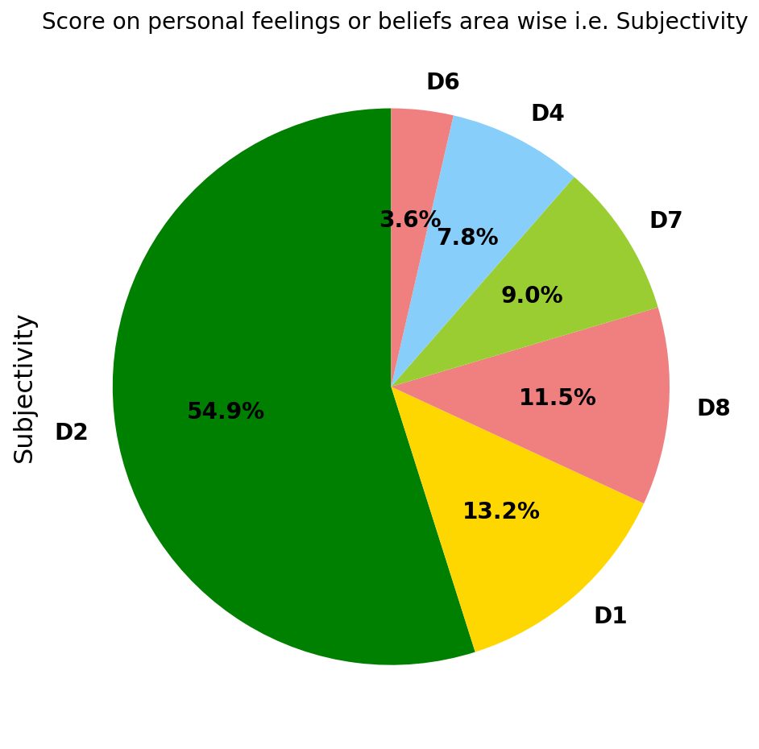

```python
review_rating_Subjectivity_Plot = review_rating_Subjectivity.head(6)

fig = plt.figure(figsize=(6,6))
ax = fig.add_axes((0,0,1,1))
mycolors=['green','gold','lightcoral','yellowgreen', 'lightskyblue', 'lightcoral', 'wheat', 'salmon', 'lavender', 'aquamarine']
w = review_rating_Subjectivity_Plot.plot(kind='pie', y = 'Subjectivity', ax=ax, autopct='%.1f%%', colors = mycolors,
        startangle=90, shadow=False, labels = review_rating_Subjectivity_Plot['ZipCode'], legend = False, fontsize=14)
w = plt.title(" Score on personal feelings or beliefs area wise i.e. Subjectivity", fontsize=14)

review_rating_Subjectivity.head(6)
```

### Creating a dataframe to visualise 'Positive, Negative and Neutral' reviews

By doing so we can visualise the sentimental score of the people who visited and gave their reviews

For this Stack plot is being used.

```python
p_reviews = review_rating.head(10)
p_reviews = p_reviews.sort_values(by=["Positive","Neutral"], ascending=False).head(10)
p_reviews
```

|  | ZipCode | ReviewRating | Polarity | Subjectivity | Positive | Negative | Neutral |
| --- | --- | --- | --- | --- | --- | --- | --- |
| 1 | D2 | 808 | 58.04 | 117.69 | 92 | 2 | 101 |
| 0 | D1 | 237 | 15.22 | 28.36 | 24 | 1 | 28 |
| 5 | D7 | 152 | 12.31 | 19.26 | 17 | 0 | 16 |
| 6 | D8 | 163 | 12.34 | 24.64 | 14 | 0 | 24 |
| 3 | D4 | 115 | 7.47 | 16.78 | 13 | 1 | 13 |
| 4 | D6 | 63 | 5.47 | 7.71 | 8 | 0 | 6 |
| 7 | D9 | 41 | 1.76 | 5.05 | 2 | 0 | 9 |
| 2 | D3 | 22 | 1.61 | 3.28 | 2 | 0 | 4 |
| 8 | D16 | 17 | 0.68 | 3.92 | 1 | 0 | 5 |
| 9 | D17 | 12 | 1.31 | 1.56 | 1 | 0 | 2 |

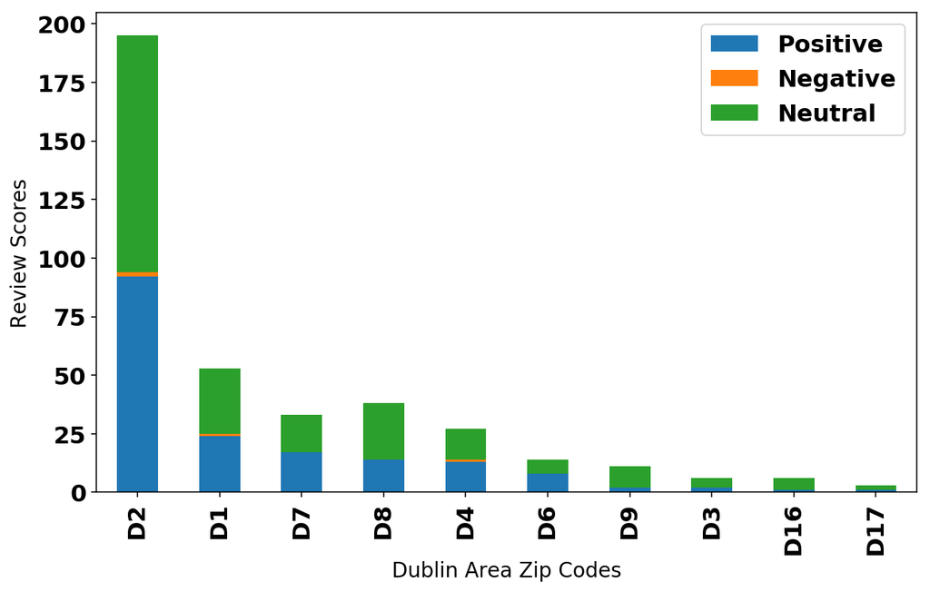

```python
p_reviews_stack = p_reviews
p_reviews_stack.index = p_reviews['ZipCode']
p = p_reviews_stack[['Positive','Negative','Neutral']].plot(kind='bar', stacked=True, figsize=(10, 6))
p.set_xlabel("Dublin Area Zip Codes",fontsize=14)
p = p.set_ylabel("Review Scores",fontsize=14)
```

# Conclusion:

- It can be clearly seen that the best area for 'Tea & Coffee' shops are present in Dublin 2.
- Dublin 2 has best rating (Score) and best reviews (Sentimentally).

#### Findings:

- After doing sentimental analysis the polarity and subjectivity defined the various aspects of feelings (Overall and in person).

#### Future Scope:

- This can be done on multiple cities and finding the best area.
- If multiple reviews of same cafe / business id can be fetched then we can see the performance of the shop over a period of time.

#### Limitation:

- Currently only 3 reviews per business id are fetched.

Best 'Tea & Coffee' store area to hang out for Dublin city is in Dublin 2.